# Distribuciones notables discretas

Christian Limbert Paredes Aguilera

23/12/2021

#library source(“funciones.R”)

# Distribución Bernoulli

Su función de probabilidad es
$$P_X(x) = \left\{\begin{array}{rcl}
1-p=q&si&x=0\\
p&si&x=1\\
0&si&\mbox{en cualquier otro caso}\\
\end{array}\right.$$

Su función de distribución es

$$P_X(x) = \left\{\begin{array}{rcl}
0&si&x<0\\
1-p=q&si&0\leq x<1\\
1&si&1\leq x\\
\end{array}\right.$$

### Esperanza de una v.a. X Ber(p)

Su valor esperado es
$$E(X) = \sum_{x=0}^1 x\cdot P(X=x) = 0\cdot(1-p)+1\cdot p = p$$

Calculemos también $E(X^2)$
$$E(X^2) = \sum_{x=o}^1 x\cdot P(X=x) = 0^2 \cdot (1-p) + 1^2\cdot p = p$$

### Varianza de una v.a. X Ber(p)

Su varianza es
$$Var(X) = E(X^2) - E^2(X) = p-p^2 = p\cdot (1-p) = p\cdot q$$

Su desviación típica es
$$\sqrt{Var(X)}=\sqrt{p\cdot (1-p)}$$

```r
#función de probabilidad
dbinom(0, size = 1, prob = 0.25)
```

```
## [1] 0.75
```

```r
#función de probabilidad
dbinom(1, size = 1, prob = 0.25)
```

```
## [1] 0.25
```

```r
# muestra aleatoria simple de probabilidad Bernoulli
rbinom(n = 20, size = 1, prob = 0.25)
```

```
##  [1] 0 0 0 0 0 0 0 0 0 0 0 1 0 0 0 0 1 1 0 0
```

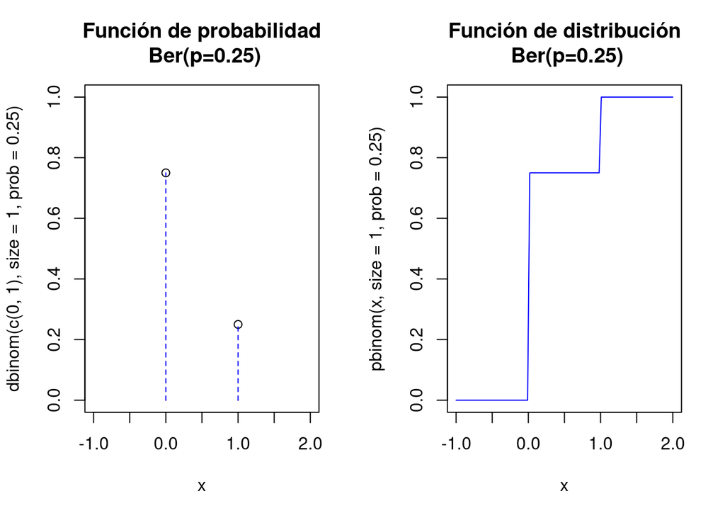

```r
# gráfico de la función de probabilidad y la de distribución de una Ber(p=0.25)
{par(mfrow=c(1,2))
plot(x=c(0,1),y=dbinom(c(0,1),size=1,prob=0.25),
     ylim=c(0,1),xlim=c(-1,2),xlab="x",
     main="Función de probabilidad\n Ber(p=0.25)")
lines(x=c(0,0,1,1),y=c(0,0.75,0,0.25), type = "h", lty = 2,col="blue")
curve(pbinom(x,size=1,prob=0.25),
      xlim=c(-1,2),col="blue",
      main="Función de distribución\n Ber(p=0.25)")
par(mfrow=c(1,1))}
```

# Distribución binomial

Si repetimos $n$ veces de forma independiente un experimento Bernoulli de parámetro $p$. Se conoce a priori cuantas veces se tirará la moneda.

El espacio muestral $\Omega$ estará formado por cadenas $E^{'} s$ y $F^{s}$ de longitud $n$ consideremos la v.a.
$$X(EFF\ldots EEF) \; = \; \mbox{número de éxitos en la cadena}$$

### Función de probabilidad de una binomial

$$P_X(x)\left\{\begin{array}{rcl}
{n \choose x}\cdot p^x \cdot (1-p)^{n-x}&si&x=0,1,\ldots,n\\
0&si&\mbox{en otro caso}\\
\end{array}\right.$$

### Función de distribución

Su función de distribución no tiene una fórmula cerrada. Hay que acumular la función de probabilidad:
$$F_X(x) = P(X\leq x) = \sum_{i=0}^x P_X(i)$$

$$P_X(x)\left\{\begin{array}{rcl}
0&si&\\
\sum_{i=1}^k {n \choose i} \cdot p^i \cdot (1-p)^{n-i}&si&k\leq x < k+1 \quad y \quad k=0,1,\ldots, n\\
1&si&n\leq x\\
\end{array}\right.$$

```r
# Cuantas maneras distintas hay para elegir 5 jugadores en un conjunto de 6 jugadores. Todo el múndo diría 6!!!!. Efectivamente con R es
choose(6,5)
```

```
## [1] 6
```

```r
# con 10 jugadores el número de equipos de 5 distintos es bastante más grande
choose(10,5)
```

```
## [1] 252
```

```r
# Y por ejemplo con un equipo de fútbol profesional que tiene en plantilla 22 jugadores (quitamos el portero) se puede formar nada menos que:
choose(22,10)
```

```
## [1] 646646
```

Se denotará por
$$X\equiv B(n,p)$$

Obviamente se tiene que una bernoulli es una binomial con $n=1$
$$B(1,p) \equiv Ber(p)$$

### Esperanza de un X B(n,p)

Su esperanza es
$$E(X) = \sum_{k=0}^n k\cdot {n \choose k}\cdot p^k \cdot q^{n-k} = n\cdot p$$

### Varianza de una X B(n,p)

Su varianza es
$$Var(X) = E(X^2) - E^2(X) = n\cdot p\cdot q = n\cdot p \cdot (1-p)$$

Su desviación típica es
$$\sqrt{n\cdot p \cdot q} = \sqrt{n\cdot p \cdot (1-p)}$$

### Caáculos binomila con R

Veamos los cálculos con funciones de R para una v.a. X con distribución binomial B(n=10,p=0.25)

Si queremos calculo con R algún valor de la función de distribución como por ejemplo $F_X(0) = P(X\leq 0)$

```r
pbinom(0,size = 10, prob = 0.25)
```

```
## [1] 0.05631351
```

si queremos por ejemplo $F_X(4) = P(X\leq 4)$

```r
pbinom(4, size = 10, prob = 0.25)
```

```
## [1] 0.9218731
```

Sin embargo, si queremos calcular algún valor de la función de probabilidad como por ejemplo $P(X=0)$

```r
dbinom(0,size=10, prob = 0.25)
```

```
## [1] 0.05631351
```

o por ejemplo para $P(X=4)$

```r
dbinom(4, size=10, prob = 0.25)
```

```
## [1] 0.145998
```

### Generación de muestras aleatorias con R

Generaremos una muestra eleatoria de 100 valores de una población B(20,0.5)

```r
# Repetir 100 veces el experimento lanzar una moneda 20 veces y contar el número de caras.
set.seed(2021)
rbinom(100, size = 20, prob = 0.5)
```

```
##   [1] 10 12 11  9 11 11 11  9 12 15  6 12 11 10 12  8 10 12 14 10  8 14  9  9 10
##  [26] 13 13 13 14 12  6 14 14 13 10  8 13  8 13 10  8 12 10 14  8 12 13  5  6 12
##  [51] 10 11  7 10  9  8 10  9 12 12  6 10  7  9 12  7  7 11  9  6  6 11  7 13  7
##  [76] 10 10  9 11 16 10  9 14 11  9  8 15 12 10  9  8 11 13 10  8 13 11 11 12 11
```

## Ejemplo completo de distribución binomial

Tenemos una urna con 100 bolas de las cuales 40 son rojas y 60 blancas. Extraemos al azar una bola, anotamos su color y la devolvemos (la reponemos) a la urna Supongamos que repetimos este proceso $n=10$ reponiendo en cada ocación la bola extraida. Consideremos la v.a. $X$ = Número de bolas extraidas con repocisión en $n=10$ repeticiones del mismo experimento Bernoulli. Bajo estas condiciones tenemos que repetimos $n=10$ veces el mismo experimento Bernoulli con probabilidad de éxito (sacar bola roja) es
$$P(Roja) = P(Exito)=p=\dfrac{40}{100}=0.4$$

Así que la variable $X$ = número de bolas rojas extraídas de la urna con reposición en $n=10$ ocasiones sigue una ley binomial $B(n=10,p=0.4)$

1.¿Cual es la probabilidad de que saquemos exactamente 4 rojas?

Respuesta.- Utilizando la función de probabilidad tenemos que
$$P_X(X=4) = {10 \choose 4} \cdot 0.4^4 \cdot (1-0.4)^10.4 = \dfrac{10!}{(10-4)!\cdot 4!}\cdot 0.4^4 \cdot 0.6^6 = 0.2508227$$

```r
dbinom(4, size = 10, prob = 0.4)
```

```
## [1] 0.2508227
```

2. ¿Cuál es la probabilidad de que saquemos al menos 4 rojas?

Respuesta.- Al menos 4 rojas es $P(X\geq 4) = 1 - P(X<4) = 1 - P(X\leq 3)$ es decir,

$$\begin{array}{rcl}
P(X\leq 3)&=&P(X=0) + P(X=1) + P(X=2) + P(X=3)\\\\
&=&\displaystyle {10\choose 0}\cdot 0.4^0 \cdot (1-0.4)^{10-0} + {10\choose 1}\cdot 0.4^1 \cdot (1-0.4)^{10-1}\\\\
&+& \displaystyle {10\choose 2}\cdot 0.4^2 \cdot (1-0.4)^{10-2} + {10\choose 3}\cdot 0.4^3 \cdot (1-0.4)^{10-3} \\\\
&=&0.3822806\\\\
\end{array}$$

```r
pbinom(3,10,0.4)
```

```
## [1] 0.3822806
```

Así, $P(X\geq 4) = 1-P(X<4) = 1 - P(X\leq 3) = 1 - 0.3822806 = 0.6177194$

```r
1-pbinom(3,10,0.4)
```

```
## [1] 0.6177194
```

Aunque en estos casos el parámetro lower.tail = FALSE es sin duda nuestra mejor opción:

```r
pbinom(3,10,0.4,lower.tail = FALSE)
```

```
## [1] 0.6177194
```

4.- ¿Cuál es el valor esperado del número de bolas rojas?

Respuesta.- Como $X$ es una $B(10,0.4)$ sabemos que
$$E(X) = n\cdot p = 10 \cdot 0.4 = 4$$

5.- ¿Cuál es la deviación típica del número de bolas rojas? La varianza es
$$Var(X) = n\cdot p \cdot (1-p) = 10\cdot 0.4 \cdot 0.6 = 2.4$$
Y por lo tanto $\sqrt{Var(X)} = \sqrt{2.4} = 1.5491933$

# Distribución geométrica

### Distribución geométrica

Su función de probabilidad es
$$PX_(x) = P(X=x) = \left\{\begin{array}{rcl}
(1-p)^x\cdot p&si&x=0,1,2,\ldots\\
0&& \mbox{en otro caso}\\
\end{array}\right.$$

La denotaremos por $Ge(p)$

### Función de distribución

Calculemos $P(X\leq 3)$.

Por la propiedad de la probabilidad del suceso complementario tenemos que
$$P(X\leq 3) = 1 -P(x>3) = 1-P(X\geq 4)$$
Efectivamente, el evento tenemos que $X\leq 3$ es que hemos fracasado más de tres veces hasta conseguir el primer éxito; es decir hemos gracasado 4 o más veces, por lo tanto
$${X>3} = {X\geq4} = {FFFF}$$

Ahora al ser los intentos sucesos independientes, tenemos que:
$$\begin{array}{rcl}
P(X>3)&=&P({FFFF}) = P(F)\cdot P(F)\cdot P(F)\cdot P(F)\\
&=&(1-p)\cdot (1-p)\cdot (1-p)\cdot (1-p) = (1-p)^{3+1} \\
&=&(1-p)^4\\
\end{array}$$

calculamos
$$F_X(3) = P(X\leq 3) = 1-P(X>3) = 1-(1-p)^{3+1}$$

por lo que podemos generalizar a cualquier entero positivo $k=0,1,2,\ldots$

$$F_X(x) = P(X\leq x) = \left\{\begin{array}{rcl}
0&si&x<0\\\\
1-(1-p)&si&k= 0 \leq x < 1\\\\
1-(1-p)^2&si& k = 1\leq x < 2\\\\
1-(1-p)^3&si& k = 2\leq x < 3\\\\
1-(1-p)^{k+1}&si& k\leq x < k+1 \; para \; k=0,1,2,\ldots\\
\end{array}\right.$$

notemos que si $k=0,1,2,\ldots$ el límite de la función de distribución es
$$\lim_{k\to \infty} F_X(k) = \lim_{k\to \infty} 1 - (1-p)^{k+1} = 1$$

ya que $0<1-p<1$

## La esperanza y la varianza de una distribución geométrica.

### Esperanza de una v.a. Ge(p)

$$\begin{array}{rcl}
E(X) &=& \sum\limits_{x=0}^\infty x \cdot P_X(x)\\
&=& \sum\limits_{x=0}^\infty x\cdot (1-p)^x \cdot p\\\
&=& p\cdot (1-p)\cdot \sum\limits_{x=1}^\infty x\cdot (1-p)^{x-1}\\
&=& p\cdot (1-p)\cdot \dfrac{1}{\left[1-(1-p)\right]^2}\\
&=&(1-p)\cdot \dfrac{1}{p^2}\\
&=&\dfrac{1-p}{p}\\
\end{array}$$

### Valor E(X^2) de una v.a. Ge(p)

$$\begin{array}{rcl}
E(X^2) &=& \sum\limits_{x=0}^\infty x^2 \cdot P_X(x)\\\\
&=& \sum\limits_{x=0}^\infty x^2 \cdot (1-p)^x \cdot p\\\\
&=& \sum\limits_{x=1}^\infty \left[x\cdot (x-1)+x \right] (1-p)^{x} \cdot p\\\\
&=&\sum\limits_{x=1}^\infty x\cdot (x-1)\cdot (1-p)^x\cdot p + \sum\limits_{x=1}^\infty x\cdot (1-p)^x \cdot p\\\\
&=&(1-p)^2\cdot p \cdot \sum\limits_{x=2}^\infty x\cdot (x-1)\cdot (1-p)^{x-2}\\\\
&+&(1-p)\cdot p\sum\limits_{x=1}^\infty x\cdot (1-p)^{x-1} \\\\
&=&p\cdot (1-p)^2 \dfrac{2}{\left[1-(1-p)\right]^3} + (1-p)\cdot p \dfrac{1}{\left[1-(1-p)\right]^2}\\\\
&=&p\cdot (1-p)^2 \dfrac{2}{p^3}+(1-p)\cdot p \dfrac{1}{p^2}\\\\
&=&\dfrac{2\cdot(1-p)^2}{p^2}+\dfrac{1-p}{p}\\
\end{array}$$

### Varianza de una v.a. Ge(p)

$$\begin{array}{rcl}
Var(X)&=&E(X^2) - E^2(X)\\\\
&=&\dfrac{2\cdot(1-p)^2}{p^2}+\dfrac{1-p}{p}-\left(\dfrac{1-p}{p}\right)^2\\\\
&=&\dfrac{2\cdot(1-p)^2+p\cdot (1-p)-(1-p)^2}{p^2}\\\\
&=&\dfrac{(1-p)^2 + p\cdot (1-p)}{p^2}\\\\
&=&\dfrac{1-2\cdot p p^2 + p - p^2}{p^2}\\\\
&=&\dfrac{1-p}{p^2}\\\\
\end{array}$$

## Propiedad de falta de memoria

Sea $X$ una v.a. discreta con dominio $D_X = \lbrace0,1,2, \ldots\rbrace$ con $P(X=0) = p$ entonces $X$ sigue una ley $Ge(p)$ si y sólo si
$$P(X> k + j \;|\; X\geq j) = P(X>k)$$
para todo $k,j = 0,1,2,3,\ldots$

Es decir, el número de veces que voy a fallar hasta el primer éxito no está condicionado por las veces que estamos probando. Por ejemplo es lo mismo lanzar 80 veces o lanzar 2 veces hasta el primer éxito.

Demostración.- Si es geométrica entonces el lado derecho de la igualdad es
$$P(X>k) = 1 - P(x\leq k) = 1 - (1-(1-p)^{k+1}) = (1-p)^{k+1}$$

Luego
$$\begin{array}{rcl}
P(X>k+j | X\geq j)&=&\dfrac{P(\lbrace X>k+j\rbrace)\cap \lbrace X\geq j\rbrace}{P(X\geq j)}\\\\
&=&\dfrac{P(X>k+j)}{P(>\geq j)}\\\\
&=&\dfrac{1-P(X\leq k+j)}{1-P(X\leq j-1)}\\\\
&=&\dfrac{1-(1-(1-p)^{k+j+1})}{1-(1-(1-p)^{k-1+1})}\\\\
&=&\dfrac{(1-p)^{k+j+1}}{(1-p)^j}\\\\
&=&(1-p)^{k+1}\\\\
\end{array}$$

Para demostrar el recíproco tomemos $j=1$ y $k\geq 0$ entonces por la propiedad de la pérdida de memoria
$$P(X>k+1 | X\geq 1) = P(X>k)$$

Como sabemos $P(X=0)=p$ tenemos $P(X\geq 1) = 1 - P(X<1) = 1-P(X=0) = 1-p$

Luego combinando las igualdades tenemos que
$$P(X<k+1 | X\geq 1) = \dfrac{P(X>k+1, X\geq 1)}{P(X\geq 1)} = \dfrac{P(X>k+1)}{P(X\geq 1)} = P(X>k)$$

Así podemos poner que
$$\begin{array}{rcl}
P(X>k+1)&=&P(X\geq 1)\cdot P(X>k)\\\\
&=&P(X<1)\cdot P(X>k)\\\\
&=&(1-P(X=0))\cdot P(X>k)\\\\
&=&(1-p)\cdot P(X>k)\\\\
\end{array}$$

En general tenemos que
$$P(X>k+1) = (1-p)\cdot P(X>k)$$

del mismo modo para $j=2$
$$P(X>k+2) = (1-p)\cdot P(X>k+1)$$
Restando la primera igualdad de la última obtenemos:
$$P(X>k+1) - P(X>k+2) = (1-p)\cdot P(X>k) - (1-p)\cdot P(X>k+1)$$
de donde operando en cada lado de la igualdad obtenemos la recurrencia
$$\left[1-P(X\leq k+1) \right] - \left[1-P(X\leq k+2)\right] = (1-p)\cdot \left[P(X>k)-P(X>k+1)\right]$$

ahora operando
$$\begin{array}{rcl}
P(X\leq k+2)-P(X\leq k+1)&=&(1-p)\cdot \left[ 1-P(X\leq k)-(1-P(X\leq k+1))\right]\\\\
P(X=k+2)&=&(1-p)\cdot \left[P(X\leq k+1)-P(X\leq k)\right]\\\\
P(X=k+2)&=&(1-p)\cdot P(X=k+1)\\\\
\end{array}$$

De forma similar obtenemos
$$P(X=k+1) = (1-p)\cdot P(X=k)$$
Utilizando la recurrencia anterior para calcular todas las probabilidades a partir de la $P(X=0)=p$; que vienen dadas por:

$$\begin{array}{rcl}
P(X=0)&=&p\\
P(X=1)&=&P(X=0+1) = (1-p)\cdot P(X=0) = (1-p)\cdot p\\
P(X=2)&=&P(X=1+1) = (1-p)\cdot P(X=1)=(1-p)\cdot (1-p)\cdot p = (1-p)^2\cdot p\\
P(X=k)&=&P(X=(k-1)+1) = (1-p)\cdot P(X=k+1) = (1-p)\cdot (1-p)^{k-1}\cdot p = (1-p)^k \cdot p\\
\end{array}$$

Lo que demuestra el recíproco, es decir que $X$ es Geom(p).

## La distribución geométrica con R y Python

Veamos los cálculos básicos con R para la distribución geométrica Ge(p=0.25). R implementa la geométrica que cuenta el número de fracasos.

$P(X=0) = (1-0.25)^0 \cdot 0.25 = 0.25$

```r
dgeom(0,prob = 0.25)
```

```
## [1] 0.25
```

$P(X\leq 0) = 1-(1-0.25)^{0+1} = 1 - 0.75 = 0.25$

```r
pgeom(0,prob = 0.25)
```

```
## [1] 0.25
```

$P(X\leq 4) = 1-(1-0.25)^{4+1} = 1-0.75^5 = 0.7626953$

```r
pgeom(4,prob = 0.25)
```

```
## [1] 0.7626953
```

Una muestra de tamaño 25 de una Ge(0.25)

```r
rgeom(n = 25, prob = 0.25)
```

```
##  [1]  2 18  3  1  7  1  0 10  2  2  2  0  9  9  4  8  2  0  1  5  8  1  1  2  2
```

# La distribución binomial negativa

### Función de probabilidad

$$P_X(x) = P(X=k) = \left\{\begin{array}{lcr}
{k+n-1 \choose n-1}\cdot (1-p)^k \cdot p^n&si&k=0,1,\ldots\\\\
0&&\mbox{en otro caso}\\
\end{array}\right.$$

## Números binomiales negativos

Dados dos enteros positivos $n$ y $k$ se define en número binomial negativo como
$${-n\choose k} = \dfrac{(-n)(-n-1)\ldots (-n-k+1)}{k!}$$

se cumple que
$$(t+1)^{-n} = \sum\limits_{k=0}^{\infty} {-n \choose k} t^k$$

Con R es la misma función que para los números binomiales

$${-6 \choose 4} = \dfrac{-6\cdot (-6-1)\cdot (-6-2) \cdot (-6-3) }{4!} = \dfrac{-6\cdot (-7)\cdot (-8)\cdot (-9)}{24} = \dfrac{3024}{24} = 126$$

```r
choose(-6,4)
```

```
## [1] 126
```

### Esperanza de una BN(n,p)

Su esperanza es
$$E(X) = \sum\limits_{k=0}^\infty k \cdot {k+n-1 \choose n-1} \cdot (1-p)^k \cdot p^n = n\cdot \dfrac{1-p}{p}$$

La esperanza del cuadrado $X^2$ es

$$E(X^2) = \sum\limits_{k=0}^\infty k^2 \cdot {k+n-1 \choose n-1} \cdot (1-p)^k \cdot p^n = n\cdot \dfrac{1-p}{p^2} + \left(n\cdot \dfrac{1-p}{p}\right)^2$$

### Varianza de una BN(n,p)

Y por tanto la desviación típica es
$$\sqrt{Var(X)} = \dfrac{\sqrt{n(1-p)}}{p}$$

## Ejemplo de la puerta con dos llaves

Tenemos un manojo de 10 llaves casi idénticas. De mnaera que cada vez que probamos una llave olvidamos qué llave hemos usado. Sea $X$ la v.a. que nos da el número de intentos fallidos hasta abrir la puerta.

#### 1.

¿Cuál es la distribución de probabilidad de $X$ la v.a. que nos da el número de fallos hasta abrir la puerta? Respuesta.- Sabemos que la probabilidad de éxito de cada intento es $p=dfrac{1}{10} = 0.1$ Como cada vez olvidamos qué llave hemos probado cada intento será independiente del anterior. Así que la variable $X$ que queremos modelar cuenta el número de fallos de repeticiones sucesivas e independientes de un experimento Ber(p=0.1) hasta conseguir 2 éxitos en un experimento. Por lo tanto podemos asegurar que $X$ sigue un distribución BN(n=2,p=0.1)

#### 2.

¿Cuál es la función de probabilidad y de distribución de $X$? Respuesta.- En general la función de probabilidad de un BN(n,p) es
$$P_X(x) = P(X=k) = \left\{ \begin{array}{ll}
{k+n-1 \choose n-1}\cdot (1-p)^k \cdot p^n&si&k=0,1,\ldots\\\\
0&&\mbox{en otro caso}\\
\end{array}\right.$$

En particular la función de probabilidad de una BN(n=2,p=0.1) es
$$P_X(x) = P(X=k) = \left\{ \begin{array}{ll}
{k+2-1 \choose 2-1}\cdot 0.9^k \cdot 0.1^2&si&k=0,1,\ldots\\\\
0&&\mbox{en otro caso}\\
\end{array}\right.$$

La función de distribución en general es
$$F_X(x) = P(X\leq x) = \left\{\begin{array}{lcl}
0&si&\\
\sum\limits_{i=1}^k {i+n-1 \choose n-1}\cdot \left(1-p\right)^{i+n-1}\cdot 0.1^n&si&x<0\\
&si&k\leq x < k+1 \; y \; k=0,1,2,\ldots\\
1&si&\mbox{en otro caso}\\
\end{array}\right.$$

Para $n=2$ y $p=0.1$

$$F_X(x) = P(X\leq x) = \left\{\begin{array}{lcl}
0&si&\\
\sum\limits_{i=1}^k {i+1 \choose 1}\cdot 0.9^{i+1}\cdot 0.1^2&si&x<0\\
&si&k\leq x < k+1 \; y \; k=0,1,2,\ldots\\
1&si&\mbox{en otro caso}\\
\end{array}\right.$$

#### 3.

¿Cuál es la probabilidad de fallar exactamente 5 veces antes de abrir la puerta? Respuesta.-
$$P(X=5) = {5+2-1\choose 1}\cdot 0.9^5 \cdot 0.1^2 = {6\choose 1}\cdot 0.9^5 \cdot 0.1^2 = 6\cdot 0.9^5 \cdot 0.1^2 = 0.0354294$$

#### 5.

¿Cuál es la probabilidad de fallar más de 4 ? Respuesta.-; Nos piden que
$$P(X>4) = 1 - P(X\leq 4)$$
Calculemos primero $P(X\leq 4):$
$$\begin{array}{rcl}
P(X\leq 4)&=&\sum\limits_{x=0}^4 P(X=x)\\\\
&=&P(X=0) + P(X=1) + P(X=2) + P(X=3) + P(X=4)\\\\
&=&{0+2-1\choose 1}\cdot 0.9^0 \cdot 0.1^2 + {1+2-1 \choose 1}\cdot 0.9^1 \cdot 0.1^2\\\\
&+&{0+2-1\choose 1}\cdot 0.9^2 \cdot 0.1^2 + {1+2-1 \choose 1}\cdot 0.9^3 \cdot 0.1^2\\\\
&+&{0+2-1\choose 1}\cdot 0.9^4 \cdot 0.1^2 \\\\
&=&0.114265\\\\
\end{array}$$

#### 5.

¿Cuál es el número esperado de fallos? ¿Y su desviación típica? Respuesta.- Como $X$ sigue una ley BN(n=2,p=0.1)
$$E(X) = n\cdot \dfrac{1-p}{p} = 2 \cdot \dfrac{1-0.1}{0.1} = 18$$

El número de fallos esperado es 18

$$Var(X) = n\cdot \dfrac{1-p}{p^2} = 2\cdot \cdot \dfrac{1-0.1}{0.1^2} = 180$$

Y su desviación típica será
$$sv(X) = \sqrt{180}$$

## La binomial negativa en R

En el ejemplo de la puerta $X$ es una BN(size = 2, p = 0.1) Por ejemplo $P(X=5)$

```r
dnbinom(5,size = 2, p = 0.1)
```

```
## [1] 0.0354294
```

Calculemos $P(X\leq 4)$

```r
pnbinom(4,size = 2, p = 0.1)
```

```
## [1] 0.114265
```

P(X>4)

```r
1-pnbinom(4,2,0.1)
```

```
## [1] 0.885735
```

```r
pnbinom(4,2,0.1,lower.tail = FALSE)
```

```
## [1] 0.885735
```

# La distribución de Poisson

Diremos que una v.a. discreta $X$ con $X(\Omega) = N$ tiene distribución de Poisson con parámetro $\lambda > 0$, y lo denotaremos por $Po(\lambda)$ si su función de probabilidad es:
$$P_X(x) = P(X=x) = \left\{\begin{array}{rcl}
\frac{\lambda^x}{x!}e^{-\lambda}&si&x=0,1,\ldots\\
0&&\mbox{en otro caso}\\
\end{array}\right.$$

Recordemos que el desarrollo en serie de taylor de la exponencial es
$$e^\lambda = \sum\limits_{x=0}^\infty \dfrac{\lambda^x}{x!}$$

Teniendo en cuenta esto es fácil comprobar que todos los valores de la función de probabilidad suman $1$.

Además recordando que dado $x\in \mathbb{R}-{0}$ se tiene que

$$\lim\limits_{n\to \infty} \left(1+\dfrac{x}{n}\right)^n = e^x$$

```r
# exponencial con serie de Taylor
eT <- function(l){
  sum <- 0
  for (i in 0:500){
    sum <- sum  + (l^i/factorial(i))
  }
  return(sum)
}

# Exponencial como límite
e <- function(x,n=100000000) (1+x/n)^n
exp(3)
```

```
## [1] 20.08554
```

```r
eT(4)
```

```
## [1] 54.59815
```

```r
e(4)
```

```
## [1] 54.59815
```

```r
exp(4)
```

```
## [1] 54.59815
```

## La distribución Poisson como límite de una binomial

## Procesos de Poisson

Cosideramos un experimento Poisson con $\lambda$ igual al promedio de eventos en una unidad de tiempo (u.t).

Si $t$ es una cantidad de tiempo en u.t., la v.a. $X_t$ = número de eventos en el intervalo $(0,t]$ es una Po(¢dot t)

El conjunto de varibales ${X_t}_{t>0}$ recibe el nombre de proceso de Poisson.

Por ejemplo si
$$n \geq 20\, \mbox{o mejor}\; n\geq 30,\; n\cdot p < 10\, \mbox{y}\; p\leq 0.05$$
la aproximación de una $B(n,p)$ por una $Po(n\cdot p)$ es buena. Sobre todo para los valores cercanos a $E(X)=\lambda$

## Ejemplo

Consideremos la v.a. X que cuenta número de insectos caídos en la trampa en una hora. Supongamos que el número promedio de insectos que captura la trampa en una hora es $E(X)=20$ y que podemos admitir que $X$ sigue una ley de probabilidad $Po(\lambda = 20)$

#### 2. Escribir de forma explicita la función de probabilidad y de distribución de X.

Repuesta.- Escribiendo de forma explicita la función de probabilidad de X. La distribución de probabilidad de un $P_0(\lambda)$ es

$$P_X(x) = P(X=x) = \left\{ \begin{array}{ll}
\frac{20^x}{x!} e^{-\lambda} & si x=0,1,,\ldots\\
0&\mbox{en otro caso}\\
\end{array}\right.$$

#### 3. Calculad la probabilidad de que en una hora caigan en la trampa exactamente 21 einsectos.

La función será
$$P(X=21)=\dfrac{20^{21}}{21!}e^{20} = 0.084$$

```r
20^21/factorial(21)*exp(-20)
```

```
## [1] 0.08460506
```

```r
dpois(21,lambda = 20)
```

```
## [1] 0.08460506
```

#### 5. ¿Cuál es el valor esperado, la varianza y la desviación típica de X?

La esperanza será
$$E(X) = \lambda = 20$$

Su varianza es
$$Var(X) = \lambda = 20$$

y la desviación típica será
$$\sqrt{Var(X)} = \sqrt{\lambda} = \sqrt{20}$$

## La Poisson con R y Python

Sea $X$ una v.a. Po(= 3). Entonces

$P_X(0)=P(X=0)$

```r
dpois(0,lambda = 3)
```

```
## [1] 0.04978707
```

$P_X(1)=P(X=1)$

```r
dpois(1,lambda = 3)
```

```
## [1] 0.1493612
```

$F_X(0) = P(X\leq 0)$

```r
ppois(0,lambda = 3)
```

```
## [1] 0.04978707
```

$F_X(1) = P(X\leq 1)$

```r
ppois(1,lambda = 3)
```

```
## [1] 0.1991483
```

Por ejemplo podemos comprobar que $F_X(10) = \sum\limits_{x=0}^{10} P_X(x)$

```r
dpois(0:10,3)
```

```
##  [1] 0.0497870684 0.1493612051 0.2240418077 0.2240418077 0.1680313557
##  [6] 0.1008188134 0.0504094067 0.0216040315 0.0081015118 0.0027005039
## [11] 0.0008101512
```

```r
sum(dpois(0:10,3))
```

```
## [1] 0.9997077
```

```r
ppois(10,3)
```

```
## [1] 0.9997077
```

Y también generar secuencias de observaciones aleatorias de unapoblación Po(3)

```r
rpois(n=100,lambda = 3)
```

```
##   [1] 0 5 4 2 3 3 1 4 4 0 1 2 1 1 4 4 4 2 2 3 3 2 4 4 3 2 3 1 2 3 1 6 2 3 0 3 2
##  [38] 1 4 5 3 2 2 2 1 1 3 2 3 2 0 2 2 1 4 7 4 5 3 4 1 2 3 4 0 3 6 1 4 0 6 2 3 3
##  [75] 0 5 4 3 2 1 0 4 0 3 8 3 4 0 5 0 3 2 5 3 8 3 2 1 4 4
```

$P(X=21)$

```r
dpois(21,lambda = 20)
```

```
## [1] 0.08460506
```

### gráficos

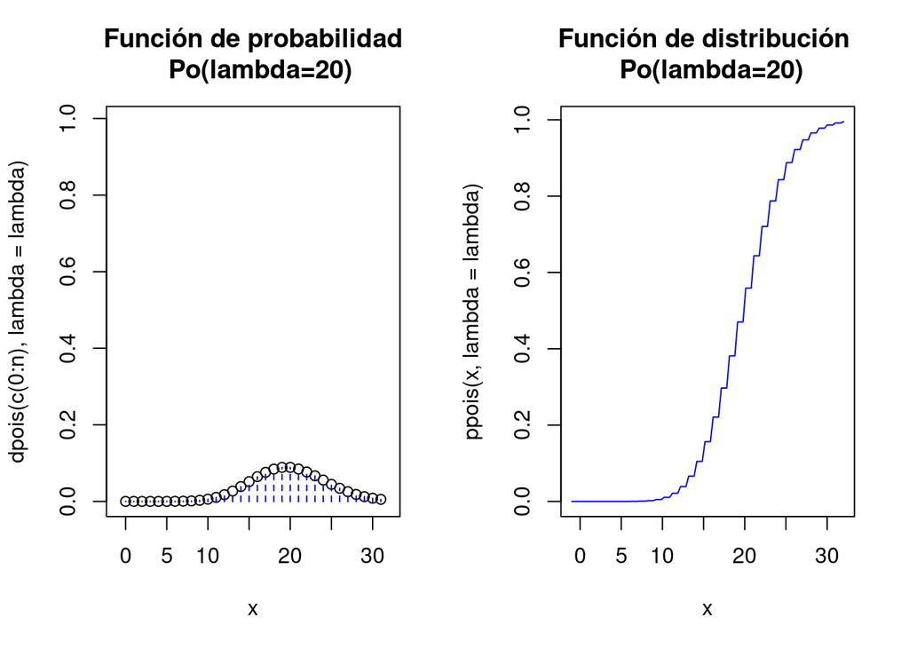

```r
{lambda=20
par(mfrow=c(1,2))
n=qpois(0.99,lambda=lambda)
aux=rep(0,(n+1)*2)
aux[seq(2,(n+1)*2,2)]=dpois(c(0:n),lambda=lambda)
ymax=max(ppois(0:n,lambda=lambda))
plot(x=c(0:n),y=dpois(c(0:n),lambda=lambda),
     ylim=c(0,ymax),xlim=c(-1,n+1),xlab="x",
     main=paste0(c("Función de probabilidad\n  Po(lambda=",lambda,")"),
                 collapse = ""))
lines(x=rep(0:n,each=2),y=aux,pch=21, type = "h", lty = 2,col="blue")
curve(ppois(x,lambda=lambda),
      xlim=c(-1,n+1),col="blue",
      main=paste0(c("Función de distribución \n Po(lambda=",lambda,")"),
                  collapse = ""))
par(mfrow=c(1,1))}
```

## Ejemplo proceso Poisson

#### 1.

¿Cuál es la probabilidad de que en 10 minutos impacten más de 25 insectos? Respuesta.- En este caso $t=10$ $X_10=$ el número de insectos que impactan en 10 minutos, el intervalo $[0,10)$ que sigue una $P(3\cdot = 30)$ por lo tanto
$$P(X>25) = 1 - p(X\leq 25)$$

```r
1-ppois(25,lambda=30)
```

```
## [1] 0.7916426
```

#### 2.

¿Cuál es la probabilidad de que tengamos que esperar más de 2 minutos para observar el primer impacto?
$$P(X_2=0) =\dfrac{(3\cdot 2)^0}{0!}\cdot e^{-3\cdot 2}=0.002479$$

```r
ppois(0,lambda = 6)
```

```
## [1] 0.002478752
```

## Tiempo entre dos ocurrencias de Poisson

$X_S \sim Poiss(\lambda_S)$ número de sucesos en el intervalo $(0,s]$

$S =$ tiempo hasta la segunda incidencia
$$\lbrace S>s\rbrace = \lbrace X_S \leq 1 \rbrace$$

$$P(S>s) = P(X_S \leq 1) = P(X_S=0)+P(X_S = 1) = \dfrac{(\lambda\cdot s)^0}{0!}e^{-\lambda\cdot s} + \dfrac{(\lambda\cdot s)^1}{1!}e^{-\lambda\cdot s} = e^{-\lambda\cdot s}(1-\lambda\cdot s),\qquad s>0$$

#### Función de distribución

$$F_S(s) = 1-P(S>s) = 1 - e^{-\lambda_S}(1+\lambda\cdot s)\qquad \lambda\cdot s>0$$

#### Función de densidad

$$f_S(s) = F_S^{'}(s) = 0 + \lambda\cdot s \cdot e^{-\lambda\cdot s}(1+\lambda\cdot s) - e^{-\lambda_S} (0+\lambda) = (\lambda\cdot s)^2 e^{-\lambda\cdot s},\quad \lambda_s>0$$

## Generalizamos tiempo entre n ocurrencias de Poisson

$X_s Poiss(s) = $ número de sucesos en $(0,s],\; s>0$ $T_r\sim$ tiempo hasta la incidencia número $r$ en el proceso de Poisson $r\geq 1$ La idea será que tendremos que hallar la densidad de
$$f_{T_r}/F_{t_r}$$
llamado también distribución gamma que es una especie del número factorial.

$$\lbrace T_r > s\rbrace = \lbrace X_S<r\rbrace = \lbrace X_S \leq r-1 \rbrace$$

$$P(T_r)>s = P(X_S\leq r-1)=\sum\limits_{i=0}^{r-1} P(X_S = i) = \sum_{i=0}^{r-1} \dfrac{(\lambda\cdot s)^i}{i!}e^{-\lambda\cdot s},\quad \lambda\cdot s>0$$

#### Función de distribución

$$F_{T_r} = 1 - P(T_r>s) = 1 - \sum_{i=0}^{r-1} \dfrac{\lambda_S^i}{i!}e^{-\lambda\cdot s} = 1-e^{-\lambda \cdot s} \cdot \sum_{i=0}^{r-1} \dfrac{(\lambda\cdot s)^i}{i!} \quad s>0$$